# Introduction à Python

## Variables

python permet de créer des variables booléennes, entières, réelles, chaines de caractère, ... de la manière la plus simple. Pas besoin de connaitre le nom des types, celui-ci est défini à l'affectation.

```python
x = 1
type(x)
```

```
int
```

```python
y = 3.1415
type(y)
```

```
float
```

```python
z = True
type(z)
```

```
bool
```

```python
s = 'Hello'
type(s)
```

```
str
```

```python
t = (1 , 1)
type(t)
```

```
tuple
```

```python
a = [ 1, 2, 3 ]
type(a)
```

```
list
```

## Affichage

Afficher le contenu d'une variable s'effectue avec la fonction print. Le format de sortie peut être maitrisé via la méthode [format](https://docs.python.org/3/library/string.html#format-string-syntax) des chaines de caractères.

```python
print(x)
print(y)
```

```
1
3.1415
```

```python
print(x,y,z)
```

```
1 3.1415 True
```

```python
print('{:>10}{:>10}{:>10}'.format('x','y','z'))
print('{:>10}{:>10}{:>10}'.format(x,y,z))
```

```
         x         y         z
         1    3.1415         1
```

Notez que contrairement au C++, le type d'une variable peut changer par affectation. Une variable python est juste un nom qui pointe vers un objet. L'affectation le fait pointer vers un autre objet. Par exemple, pour `x` qui est jusqu'ici de type `int`

```python
x = 3.14
type(x)
```

```
float
```

## Décisions

Les décisions en python se font via l'instruction `if`, `elif`, `else` corresponant au `if`, `else if`, `else` du C++. L'expression booléenne testée est suivie de `:`, la branche de code à exécuter est écrite sur la/les lignes suivantes indentées.

```python
x = 1.4

if x < 0:
    print(x,'est négatif')
elif x == 0:
    print(x,'est nul')
else:
    print(x,'est positif')
```

```
1.4 est positif
```

Notez que la définition des blocs de code se fait par indentation, contrairement au C++ qui utilise les accolades `{...}`

```python
x = 1.4

if x < 0:
    print(x,'est négatif')
elif x == 0:
    print(x,'est nul')
else:
    print(x,'est positif')
    if x > 2:
        print('et plus grand que 2')
        print('ça fait beaucoup')
    print('mais pas trop')
```

```
1.4 est positif
mais pas trop
```

## Boucles

python dispose de boucles `while` et `for` mais pas de boucle `do ... while`. La syntaxe des boucles while est quasi identique à celle des décisions ci-dessus

```python
x = -5

while x < 0:
    print(x)
    x += 1

print('fin de boucle: x vaut',x)
```

```
-5
-4
-3
-2
-1
fin de boucle: x vaut 0
```

La boucle `for` sert uniquement à itérer sur les éléments d'une séquence (tableau, liste, caractères d'une chaine), similairement à la syntaxe `for(auto c : s)` du C++ par exemple.

```python
s = "Hello"
for c in s:
    print(c)
```

```
H
e
l
l
o
```

Si l'on veut écrire l'équivalent du boucle

`for(int i = 0; i < N; ++i)`

en C++, il faut créer une séquence contenant les entiers de 0 à N-1. On utilise pour cela `range(0,N)`.

```python
for i in range(0,5):
    print(i,i**2)
```

```
0 0
1 1
2 4
3 9
4 16
```

```python
for i in range(0,10,2):
    print(i,i**3)
```

```
0 0
2 8
4 64
6 216
8 512
```

```python
for i in range(5,0,-1):
    print(i,i**4)
```

```
5 625
4 256
3 81
2 16
1 1
```

## Fonctions

python permet de définir des fonctions avec le mot clé `def`

```python
def hello(name, loud):
    if loud:
        print('HELLO', name.upper(), '!')
    else:
        print('Hello', name)
```

```python
hello('Adam',False)
hello('Bob',True)
```

```
Hello Adam
HELLO BOB !
```

La fonction précédente n'a pas de valeur de retour. Le mot clé `return` permet d'en retourner une ... ou plusieurs

```python
def somme(a,b):
    s = a+b
    return s
```

```python
x = 1
y = 2
s1 = somme(x,y)
print('somme = ',s1)
```

```
somme =  3
```

```python
def sommeEtDiff(a,b):
    s = a+b
    d = a-b
    return s,d
```

```python
s2,d2 = sommeEtDiff(x,y)
print('somme = {0} et difference = {1}'.format(s2,d2))
```

```
somme = 3 et difference = -1
```

Les paramètres peuvent avoir des valeurs par défaut

```python
def puissance(exp1,exp2,base=10,step=1):
    for exp in range(exp1,exp2,step):
        print(base**exp)
```

```python
puissance(0,3)          # exp1 = 0 et exp2 = 3
```

```
1
10
100
```

```python
puissance(0,3,2)        # exp1 = 0, exp2 = 3 et base = 2
```

```
1
2
4
```

Il est aussi possible de passer les paramètres dans le désordre en spécifiant leurs noms.

```python
puissance(0,10,step=3)  # exp1 = 0, exp2 = 10 et step = 3
```

```
1
1000
1000000
1000000000
```

```python
puissance(base=2,exp2=10,exp1=0,step=3)
```

```
1
8
64
512
```

## Tableaux

Les tableaux les plus utilisés sont de type `list`, même s'ils sont en pratique mis en oeuvre sous la forme de tableaux redimensionable, similairement à la classe `vector` en C++.

```python
T = [ 6, 3, 5, 1, 2, 4 ]
print(T)
type(T)
```

```
[6, 3, 5, 1, 2, 4]
```

```
list
```

Parcourir tous les éléments du tableau se fait avec la boucle `for`

```python
for t in T:
    print(t)
```

```
6
3
5
1
2
4
```

On dispose d'un accès par indice avec les crochets `[]`. Parcourir tout les indices du tableau utilise la séquence `range` vue plus haut et la fonction `len` qui retourne la taille de la liste

```python
for i in range(0,len(T)):
    T[i] = T[i]**2
print(T)
```

```
[36, 9, 25, 1, 4, 16]
```

Si nécessaire, la fonction `enumerate` permet un accès simultané aux indices et aux éléments

```python
for i, t in enumerate(T):
    print("T[",i,"] =",t)
```

```
T[ 0 ] = 36
T[ 1 ] = 9
T[ 2 ] = 25
T[ 3 ] = 1
T[ 4 ] = 4
T[ 5 ] = 16
```

Les tableaux sont redimensionables. En particulier on dispose de la méthode `append` qui correspond à `push_back` en C++.

```python
T2 = []
for t in T:
    T2.append(t+1)
print(T2)
```

```
[37, 10, 26, 2, 5, 17]
```

Mais il y a une syntaxe plus élégante en python pour écrire la boucle ci-dessus. Elle sera utilisée dans ce cours.

```python
T3 = [ t+1 for t in T ]
print(T3)
```

```
[37, 10, 26, 2, 5, 17]
```

Enfin, on peut facilement créer des sous-tableaux en en prenant une tranche (slice)

```python
print(T)
print(T[1:4])
print(T[:2],T[2:])
```

```
[36, 9, 25, 1, 4, 16]
[9, 25, 1]
[36, 9] [25, 1, 4, 16]
```

## Librairies

De très nombreuses librairies étendent les fonctionalités de python. Pour les utiliser, on utilise le mot clé `import` ou `import ... as ...` pour la renommer. Dans le cadre de ce cours, nous utiliserons essentiellement la librairie numérique [numpy](http://www.numpy.org) et celle de dessin de graphes 2d [matplotlib](https://matplotlib.org) .

Voyons comment dessiner le graphe d'une fonction sinus

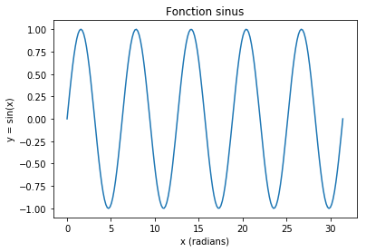

```python
import numpy as np
import matplotlib.pyplot as plt

x = np.linspace(0,10*np.pi,200)
y = np.sin(x)

plt.plot(x,y)
plt.title('Fonction sinus')
plt.xlabel('x (radians)')
plt.ylabel('y = sin(x)')
plt.show()
```

## Graphes

Une fonction particulièrement utile pour la suite est la possibilité d'afficher des graphes avec des échelles linéaires ou logarithmique pour chacun des axes.

```python
x = np.linspace(0,100,11)
print(x)
```

```
[  0.  10.  20.  30.  40.  50.  60.  70.  80.  90. 100.]
```

```python
x = np.logspace(0,2,11)
print(x)
```

```
[  1.           1.58489319   2.51188643   3.98107171   6.30957344
  10.          15.84893192  25.11886432  39.81071706  63.09573445
 100.        ]
```

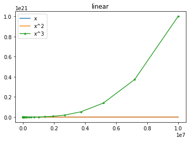

```python
x = np.logspace(0,7,50)
y = np.square(x)
z = np.power(x,3)

plt.plot(x,x,label='x')
plt.plot(x,y,label='x^2')
plt.plot(x,z,label='x^3',marker='.')
plt.legend()
plt.title('linear')
plt.show()
```

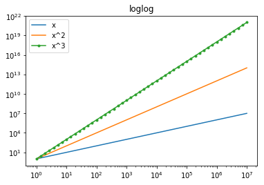

```python
plt.loglog(x,x,label='x')
plt.loglog(x,y,label='x^2')
plt.loglog(x,z,label='x^3',marker='.')
plt.legend()
plt.title('loglog')
plt.show()
```

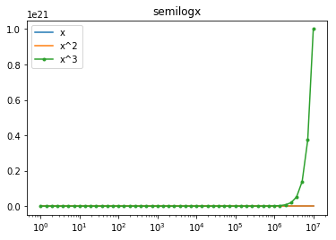

```python
plt.semilogx(x,x,label='x')
plt.semilogx(x,y,label='x^2')
plt.semilogx(x,z,label='x^3',marker='.')
plt.legend()
plt.title('semilogx')
plt.show()
```

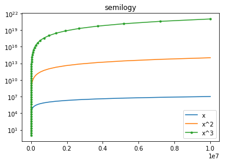

```python
plt.semilogy(x,x,label='x')
plt.semilogy(x,y,label='x^2')
plt.semilogy(x,z,label='x^3',marker='.')
plt.legend()
plt.title('semilogy')
plt.show()
```

## Nombres aléatoires

```python
import random

random.random()           # nombre aléatoire entre 0 et 1
```

```
0.6203232130165383
```

```python
random.randint(0,100)     # entier aléatoire entre 0 et 100 (100 y compris)
```

```
92
```

```python
random.uniform(0,100)     # nombre aléatoire entre 0 et 100, distribution uniforme
```

```
55.40150502304532
```

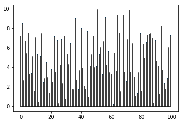

```python
T = np.random.uniform(0,10,100)    # 100 nombres aléatoires entre 0 et 10

plt.stem(T,markerfmt=',',linefmt='black',basefmt='black')
plt.show()
```

|  | [ASD1 Notebooks on GitHub.io](https://ocuisenaire.github.io/ASD1-notebooks/) © Olivier Cuisenaire, 2018 |
| --- | --- |